# 301.0. DP1 overview

For the Rubin Science Platform at data.lsst.cloud.  
Data Release: [Data Preview 1](http://dp1.lsst.io)  
Container Size: large  
LSST Science Pipelines version: r29.2.0  
Last verified to run: 2025-09-02  
Repository: github.com/lsst/tutorial-notebooks

**Learning objective:** To gain an overview of the target fields of Data Preview 1 (DP1) data taken with LSSTComCam.

**LSST data products:**

**Packages:** `lsst.daf.butler`, `lsst.rsp`, `lsst.geom`

**Credit:** Originally developed by Andrés A. Plazas Malagón and the Rubin Community Science team. Sections 3, 4, and 5 are based on notebooks developed for the DP1 paper in github.com/lsst/rtn-095. Please consider acknowledging them if this notebook is used for the preparation of journal articles, software releases, or other notebooks.

**Get Support:** Everyone is encouraged to ask questions or raise issues in the [Support Category](https://community.lsst.org/c/support) of the Rubin Community Forum. Rubin staff will respond to all questions posted there.

## 1. Introduction

This notebook provides an overview and exploratory analysis of the seven target fields observed during the ComCam on-sky commissioning campaign of the Vera C. Rubin Observatory.

Between October and December 2024, ComCam was used to acquire ∼16,000 exposures for systems engineering, science performance validation, and early data processing trials ([SITCOMTN-149](https://sitcomtn-149.lsst.io/)). A subset of these exposures formed the foundation of **Data Preview 1 (DP1)**, offering the science community an opportunity to gain experience with real LSST-like data and tools. Each field was selected to support specific validation goals and LSST science use cases, covering a broad range of sky locations, object densities, and overlap with external datasets.

**Related tutorials**: Other tutorials in the 301 series about ComCam fields during commissioning.

### 1.1. Field descriptions

**47 Tuc**  
A crowded stellar field, 47 Tucanae was targeted for early testing of image quality and Active Optics System (AOS) alignment performance. The high stellar density of this field makes it ideal for testing crowded-field photometry pipelines.

**Low Ecliptic Latitude Field (Rubin SV 38 7)**  
This low ecliptic latitude field was selected to optimize Solar System science. It was observed using a 2x2 dithered grid pattern to facilitate tracking of moving objects across a larger region. This field supports time-domain science and tests related to Solar System Object association.

**Fornax Dwarf Spheroidal (dSph) Galaxy**  
Centered on the Fornax Dwarf Spheroidal Galaxy, this field is ideal for studying resolved stellar populations in a Local Group dwarf galaxy.

**Extended Chandra Deep Field South (ECDFS)**  
The Extended Chandra Deep Field South (ECDFS) received the densest and most temporally consistent coverage among all fields, with hundreds of visits across all six bands. It was used as the main field for photometric calibration validation using FGCM (Forward Global Calibration Method), and includes the CalSpec star C26202.

**Low Galactic Latitude Field (Rubin SV 95 -25)**  
Located at low Galactic latitude, this field has a very high stellar density and is relevant for Galactic structure studies.

**Seagull Nebula**  
Targeting a region near the Seagull Nebula, this field supports ISM and star formation studies. It has moderately high stellar density and was included to explore structured backgrounds and variations in image quality and calibration.

#### 1.1.1. Stellar densities

Stellar densities vary significantly across the fields and were a major consideration during field selection. Fields such as **47 Tuc** and **Rubin SV 95 -25** contain high-density stellar regions, testing the limits of the photometric and astrometric pipelines under crowded conditions. In contrast, **ECDFS** and **EDFS** are extragalactic fields with sparse stellar populations, supporting deep coadditions and weak lensing science.

#### 1.1.2. Temporal cadence

Temporal cadence also varies by field and was driven by science goals and operational feasibility. **ECDFS** had the most uniform and nightly sampling, supporting difference imaging and photometric calibration studies. **Rubin SV 38 7** was revisited with a structured dither pattern across multiple nights to enable Solar System science. Other fields, such as **Seagull** and **Fornax**, received sparser but still valuable coverage across filters and nights.

#### 1.1.3. Summary table

See also the figure in Section 3.3.

[output not shown]

### 1.2. Import packages

Import `numpy`, a fundamental package for scientific computing with arrays in Python (numpy.org), and `matplotlib`, a comprehensive library for data visualization ([matplotlib.org](https://matplotlib.org/); [matplotlib gallery](https://matplotlib.org/stable/gallery/index.html)).

From the `lsst` package, import modules for accessing the Table Access Protocol (TAP) service, the butler, and geometry utilities from the LSST Science Pipelines ([pipelines.lsst.io](https://pipelines.lsst.io/)).

From `astropy`, import modules for celestial coordinate transformations, units, and tables  
([astropy.org](https://www.astropy.org/)), and `astroplan` for working with astronomical targets.

Use `skyproj`, a specialized sky projection package, to create consistent sky maps  
([skyproj](https://skyproj.readthedocs.io/en/latest/)).

Use the plotting utilities in `lsst.utils.plotting` to access LSST-standard color schemes, symbols, and line styles for multi-band visualizations.

```python
import numpy as np
import matplotlib.pyplot as plt
from astropy.coordinates import SkyCoord
import astropy.units as u
import skyproj

from lsst.rsp import get_tap_service
from lsst.daf.butler import Butler
from lsst.utils.plotting import (
    get_multiband_plot_colors,
    get_multiband_plot_symbols,
    get_multiband_plot_linestyles
)
```

### 1.3. Define parameters and functions

Instantiate the Butler with the appropiate DP1 repository, collection, and skymap.

```python
butler = Butler('dp1', collections='LSSTComCam/DP1')
assert butler is not None
```

Instantiate the TAP service.

```python
service = get_tap_service("tap")
assert service is not None
```

Define colors, symbols, and linestyles to represent the six LSST filters, $ugrizy$, as defined in RTN-045.

```python
filter_names = ['u', 'g', 'r', 'i', 'z', 'y']
filter_colors = get_multiband_plot_colors()
filter_symbols = get_multiband_plot_symbols()
filter_linestyles = get_multiband_plot_linestyles()
```

Define a dictionary with each field's name and central coordinates, Right Ascension and Declination, as defined in [SITCOMTN-149](https://sitcomtn-149.lsst.io/). The following are International Celestial Reference System (ICRS) coordinates, shared in units of decimal degrees.

```python
field_centers = {
    "47 Tuc": [6.02, -72.08],
    "SV 38 7": [37.86, 6.98],
    "Fornax": [40.00, -34.45],
    "ECDFS": [53.13, -28.10],
    "EDFS": [59.10, -48.73],
    "SV 95 -25": [95.00, -25.00],
    "Seagull": [106.23, -10.51],
}
field_names = list(field_centers.keys())
```

## 2. Sky map

Use `skyproj` to visualize the fields on the celestial spehere.

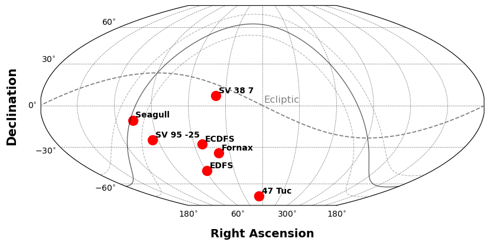

```python
fig, ax = plt.subplots(figsize=(8, 4))
sp = skyproj.McBrydeSkyproj(ax=ax, celestial=True, galactic=False, gridlines=True)
sp.ax.set_xlabel("Right Ascension", fontsize=14, fontweight="bold", labelpad=12)
sp.ax.set_ylabel("Declination", fontsize=15, fontweight="bold", labelpad=12)

for name, (ra, dec) in field_centers.items():
    sp.ax.plot(ra, dec, marker="o", color="red", markersize=11.5)
    x, y = sp.proj(ra, dec)
    sp.ax.annotate(name, (x, y), fontsize=10, fontweight="bold",
                   textcoords="offset points", xytext=(3.4, 3.4))

ecl_lon = np.linspace(0, 360, 1000)
ecl_lat = np.zeros_like(ecl_lon)
ecl_eq = SkyCoord(ecl_lon * u.deg, ecl_lat * u.deg,
                  frame="geocentrictrueecliptic").transform_to("icrs")
ecl_ra = ecl_eq.ra.deg
ecl_dec = ecl_eq.dec.deg

sp.ax.plot(ecl_ra, ecl_dec, color="gray", linestyle="--", lw=1.3, zorder=5)
sp.ax.text(*sp.proj(260, 50), "Ecliptic", fontsize=12, color="gray",
           ha="left", va="bottom")

l_vals = np.linspace(0, 360, 1000)
for b in [0, 10, -10]:
    gal = SkyCoord(l_vals * u.deg, b * u.deg, frame="galactic")
    eq = gal.transform_to("icrs")
    sp.ax.plot(eq.ra.deg, eq.dec.deg,
               color="black" if b == 0 else "gray",
               linestyle="-" if b == 0 else "--",
               lw=1.0 if b == 0 else 0.8, alpha=0.6)

sp.ax.gridlines.set_edgecolor("black")
sp.ax.gridlines.set_linestyle("--")
sp.ax.gridlines.set_alpha(0.3)
sp.ax.gridlines.zorder = 0
plt.tight_layout()
plt.show()
```

> **Figure 1:** An all-sky view with the seven DP1 fields marked with red circles and labeled by name.

## 3. Visits

Use the TAP service to return the visit id, coordinates, band, and MJD of all visits.

```python
query = """SELECT visit, ra, dec, band, expMidptMJD
        FROM dp1.Visit
        ORDER BY visit ASC"""
job = service.submit_job(query)
job.run()
job.wait(phases=['COMPLETED', 'ERROR'])
print('Job phase is', job.phase)
if job.phase == 'ERROR':
    job.raise_if_error()
assert job.phase == 'COMPLETED'
visits = job.fetch_result().to_table()
del query, job
```

```
Job phase is COMPLETED
```

### 3.1. Filter distributions

Print the number of visits per filter, per field, and the total per field.

```python
print('Field       visits per filter       total')
print('             u   g   r   i   z   y  ')
for i in range(len(field_names)):
    name = field_names[i]
    ra, dec = field_centers[name]
    offsets = np.sqrt((visits['ra']-ra)**2
                      + (visits['dec']-dec)**2)
    tx = np.where(offsets < 3.0)[0]
    tmp = np.zeros(6, dtype='int')
    for f, filt in enumerate(filter_names):
        tmp[f] = len(np.where(visits['band'][tx] == filt)[0])
    print('%-10s %3i %3i %3i %3i %3i %3i   %3i' %
          (name, tmp[0], tmp[1], tmp[2], tmp[3], tmp[4], tmp[5], len(tx)))
    del name, ra, dec, offsets, tx, tmp
```

```
Field       visits per filter       total
             u   g   r   i   z   y
47 Tuc       0  10  32  19   0   5    66
SV 38 7      0  44  40  55  20   0   159
Fornax       0   5  25  12   0   0    42
ECDFS       43 230 237 162 153  30   855
EDFS        20  61  87  42  42  20   272
SV 95 -25   33  82  84  23  60  10   292
Seagull     10  37  43   0  10   0   100
```

### 3.2. Epochs (nights)

Print the number of nights the field was observed, and the average number of visits per night.

```python
print('Field     # nights    mean visits/night')
for i in range(len(field_names)):
    name = field_names[i]
    ra, dec = field_centers[name]
    offsets = np.sqrt((visits['ra']-ra)**2
                      + (visits['dec']-dec)**2)
    tx = np.where(offsets < 3.0)[0]
    days = np.floor(visits['expMidptMJD'][tx])
    values, counts = np.unique(days, return_counts=True)
    tmp1 = len(values)
    tmp2 = np.mean(counts)
    print('%-10s  %3i       %2.1f' % (name, tmp1, tmp2))
    del name, ra, dec, offsets, tx
    del days, values, counts, tmp1, tmp2
```

```
Field     # nights    mean visits/night
47 Tuc        4       16.5
SV 38 7       5       31.8
Fornax        2       21.0
ECDFS        21       40.7
EDFS          9       30.2
SV 95 -25    10       29.2
Seagull       4       25.0
```

### 3.3. Temporal cadence

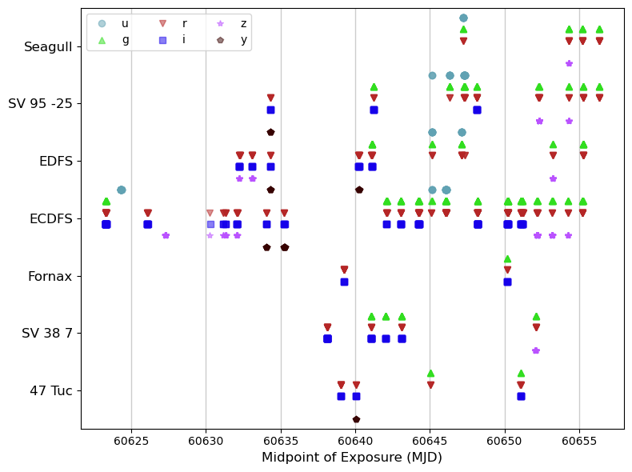

```python
plt.figure(figsize=(8, 6))
spacing = 0.6

for i in range(len(field_names)):
    name = field_names[i]
    ra, dec = field_centers[name]
    offsets = np.sqrt((visits['ra']-ra)**2
                      + (visits['dec']-dec)**2)
    tx = np.where(offsets < 3.0)[0]
    for f, filt in enumerate(filter_names):
        fx = np.where(visits['band'][tx] == filt)[0]
        if len(fx) > 0:
            yval = (i * spacing) - (f * 0.12) + 0.3
            for j in range(len(fx)):
                plt.plot(visits['expMidptMJD'][tx[fx[j]]], yval,
                         filter_symbols[filt], alpha=0.5,
                         color=filter_colors[filt],
                         label=filt if (j == 0) & (i == 3) else None)

yticks = [i * spacing for i in range(len(field_names))]
plt.yticks(yticks, [t for t in field_names], fontsize=12)
plt.xlabel("Midpoint of Exposure (MJD)", fontsize=12)
plt.grid(axis='x', color='0.8', linewidth=1)
plt.legend(loc='upper left', ncol=3)
plt.ylim(-spacing / 1.5, (len(field_names) - 1) * spacing + spacing / 1.5)
plt.tight_layout()
```

## 4. Image quality

Use the TAP service to return the seeing and magnitude limits that were evaluated for all `visit_images` (all detectors) from the `CcdVisit` table.

```python
query = """SELECT visitId, ra, dec, band, seeing, magLim
        FROM dp1.CcdVisit
        ORDER BY visitId ASC"""
job = service.submit_job(query)
job.run()
job.wait(phases=['COMPLETED', 'ERROR'])
print('Job phase is', job.phase)
if job.phase == 'ERROR':
    job.raise_if_error()
assert job.phase == 'COMPLETED'
ccdvisits = job.fetch_result().to_table()
del query, job
```

```
Job phase is COMPLETED
```

### 4.1. Seeing

Calculate the average seeing over all detectors by filter, and for all filters.

```python
print('Field      seeing per filter               mean')
print('              u    g    r    i    z    y  ')
for i in range(len(field_names)):
    name = field_names[i]
    ra, dec = field_centers[name]
    offsets = np.sqrt((ccdvisits['ra']-ra)**2
                      + (ccdvisits['dec']-dec)**2)
    tx = np.where(offsets < 3.0)[0]
    tmp = []
    for f, filt in enumerate(filter_names):
        fx = np.where(ccdvisits['band'][tx] == filt)[0]
        if len(fx) > 0:
            tmp.append(str(np.round(np.mean(ccdvisits['seeing'][tx[fx]]), 2)))
        else:
            tmp.append('  - ')
    tmp.append(str(np.round(np.mean(ccdvisits['seeing'][tx]), 2)))
    print('%-10s %-4s %-4s %-4s %-4s %-4s %-4s   %-4s' %
          (name, tmp[0], tmp[1], tmp[2], tmp[3], tmp[4], tmp[5], tmp[6]))
    del name, ra, dec, offsets, tx
```

```
Field      seeing per filter               mean
              u    g    r    i    z    y
47 Tuc       -  1.47 1.26 1.11   -  1.34   1.25
SV 38 7      -  1.16 1.13 1.11 1.23   -    1.14
Fornax       -  1.16 0.83 0.87   -    -    0.88
ECDFS      1.43 1.17 1.09 1.01 1.0  1.07   1.1
EDFS       1.88 1.2  1.2  1.05 1.17 0.98   1.21
SV 95 -25  1.48 1.24 1.13 0.99 1.23 0.83   1.2
Seagull    1.53 1.26 1.12   -  1.21   -    1.22
```

### 4.2. Magnitude limits

Calculate the average magnitude limit over all detectors by filter, and for all filters.

```python
print('Field      mag lim per filter                   mean')
print('              u     g     r     i     z     y  ')
for i in range(len(field_names)):
    name = field_names[i]
    ra, dec = field_centers[name]
    offsets = np.sqrt((ccdvisits['ra']-ra)**2
                      + (ccdvisits['dec']-dec)**2)
    tx = np.where(offsets < 3.0)[0]
    tmp = []
    for f, filt in enumerate(filter_names):
        fx = np.where(ccdvisits['band'][tx] == filt)[0]
        if len(fx) > 0:
            tmp.append(str(np.round(np.mean(ccdvisits['magLim'][tx[fx]]), 2)))
        else:
            tmp.append('  - ')
    tmp.append(str(np.round(np.mean(ccdvisits['magLim'][tx]), 2)))
    print('%-10s %-5s %-5s %-5s %-5s %-5s %-5s   %-5s' %
          (name, tmp[0], tmp[1], tmp[2], tmp[3], tmp[4], tmp[5], tmp[6]))
    del name, ra, dec, offsets, tx
```

```
Field      mag lim per filter                   mean
              u     g     r     i     z     y
47 Tuc       -   24.16 24.28 23.99   -   21.7    23.98
SV 38 7      -   24.45 24.19 23.74 22.9    -     23.94
Fornax       -   24.78 24.74 24.15   -     -     24.58
ECDFS      23.5  24.49 24.15 23.9  23.14 21.94   23.9
EDFS       23.3  24.57 24.15 23.87 23.18 22.15   23.84
SV 95 -25  23.54 24.63 24.36 23.95 23.12 22.17   23.98
Seagull    23.38 24.02 23.76   -   23.18   -     23.76
```

## 5. Coadded depth

Use the survey property maps to print the coadded depth in each band in the center of each field.

Load the PSF magnitude limits in each filter.

```python
u_maglim = butler.get('deepCoadd_psf_maglim_consolidated_map_weighted_mean',
                      band='u')
g_maglim = butler.get('deepCoadd_psf_maglim_consolidated_map_weighted_mean',
                      band='g')
r_maglim = butler.get('deepCoadd_psf_maglim_consolidated_map_weighted_mean',
                      band='r')
i_maglim = butler.get('deepCoadd_psf_maglim_consolidated_map_weighted_mean',
                      band='i')
z_maglim = butler.get('deepCoadd_psf_maglim_consolidated_map_weighted_mean',
                      band='z')
y_maglim = butler.get('deepCoadd_psf_maglim_consolidated_map_weighted_mean',
                      band='y')
```

Print the value per filter at the center of each field. Where there is no data, print "nan". Notice that all the depths for 47 Tuc are evaluated to be "nan", and the reason why is explored in Section 5.1.

```python
print('Field      coadded mag lim per filter        ')
print('              u     g     r     i     z     y')
for i in range(len(field_names)):
    name = field_names[i]
    ra, dec = field_centers[name]
    lims = np.asarray([u_maglim.get_values_pos(ra, dec),
                       g_maglim.get_values_pos(ra, dec),
                       r_maglim.get_values_pos(ra, dec),
                       i_maglim.get_values_pos(ra, dec),
                       z_maglim.get_values_pos(ra, dec),
                       y_maglim.get_values_pos(ra, dec)], dtype='float')
    tx = np.where(lims < 0.0)[0]
    lims[tx] = float('NaN')
    print('%-10s %5.2f %5.2f %5.2f %5.2f %5.2f %5.2f' %
          (name, lims[0], lims[1], lims[2], lims[3], lims[4], lims[5]))
```

```
Field      coadded mag lim per filter
              u     g     r     i     z     y
47 Tuc       nan   nan   nan   nan   nan   nan
SV 38 7      nan 25.29 25.06 24.72 23.49   nan
Fornax       nan   nan 25.08 25.31   nan   nan
ECDFS      25.18 27.36 27.09 26.50 25.61 23.57
EDFS       23.89 26.53 26.47 25.73 24.98 23.57
SV 95 -25  25.12 26.74 26.53 25.44 25.14 23.28
Seagull    24.32 25.83 25.57   nan 24.09   nan
```

> **Warning!** The coadded depth in the **center of 47 Tuc** is not evaluated (not a number, "nan"). Proceed to the next section to understand why.

### 5.1. Depth maps

Plot the r-band depth maps for every field. Notice that 47 Tuc has a "hole" in the center, where there field was too crowded for the images to be processed for Data Preview 1. Software improvements and configuration tuning are underway to be able to handle such crowded fields.

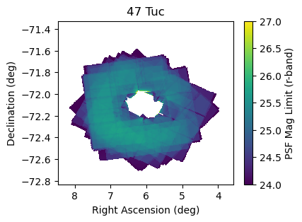

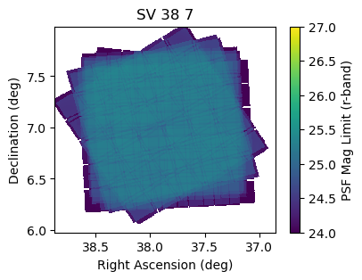

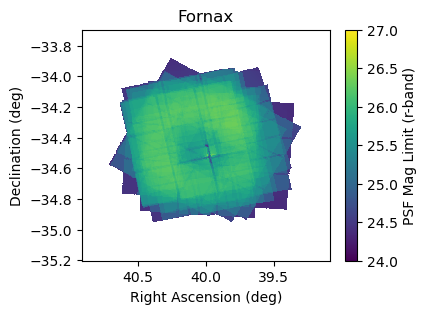

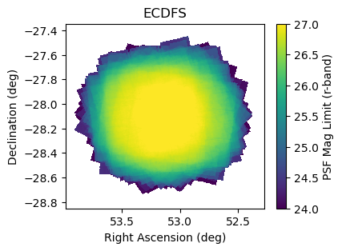

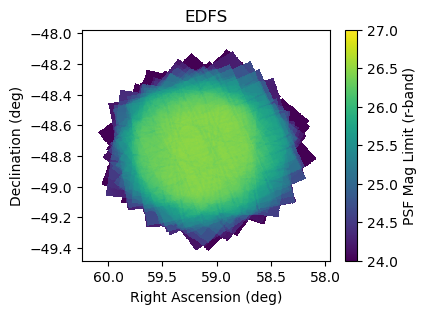

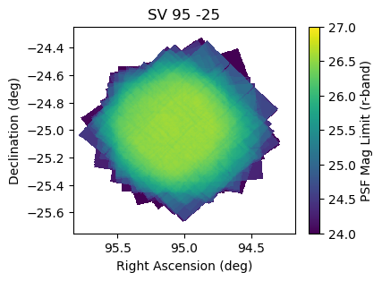

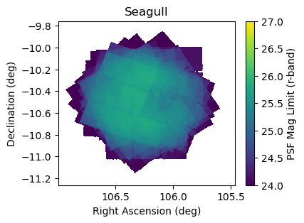

```python
for i in range(len(field_names)):
    name = field_names[i]
    ra_cen, dec_cen = field_centers[name]
    span_dec = 0.75
    if i == 1:
        span_dec = 1.00
    span_ra = span_dec / np.cos(np.deg2rad(dec_cen))
    ra = np.linspace(ra_cen-span_ra, ra_cen+span_ra, 250)
    dec = np.linspace(dec_cen-span_dec, dec_cen+span_dec, 250)
    x, y = np.meshgrid(ra, dec)
    values = r_maglim.get_values_pos(x, y)
    row, col = np.where(values < 0.0)
    values[row, col] = 'NaN'

    fig = plt.figure(figsize=(4, 3))
    plt.pcolormesh(x, y, values, vmin=24.0, vmax=27)
    plt.xlabel("Right Ascension (deg)")
    plt.ylabel("Declination (deg)")
    plt.title(name)
    plt.colorbar(label="PSF Mag Limit (r-band)")
    plt.gca().invert_xaxis()
    plt.show()
```

> **Figure 2:** Seven panels showing the r-band depth survey property map for each field.